# AFL: Player attribute influence on results

## Revisit: Purpose & Objective

**As coach, how can I build, select or train my AFL team to maximise success?** (game snippet: youtube.com/watch?v=QH188gSGnsk)

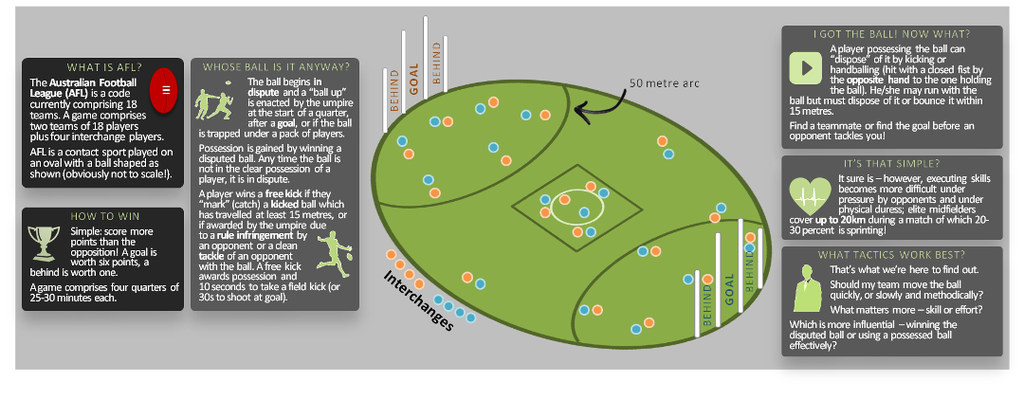

### Hypothesis

The core hypothesis of the analysis is that **AFL player performance data** recorded from competitive matches can be used to identify key success criteria and in turn **predict match results**.

## Data sources and key variables

Data on the most recent 15 AFL seasons has been wrangled into two data frames:

- Player metrics, forming the x variables to be aggregated at team level to explain and predict match results, and
- Team results, the y variable I am seeking to predict.

```r
  head(data.frame(player.metrics), 5)
```

```
##             Player     Team Year round Played_pct Behinds Bounces Clangers Clearances Contested_marks Contested_possessions Disposals Frees Frees_against Goal_assists Goals Handballs Hit_outs
## 1     Atkins, Rory Adelaide 2017   R01         82       0       4        2          1               0                     6        19     1             0            2     3         5        0
## 2     Betts, Eddie Adelaide 2017   R01         88       2       2        4          1               0                     4        18     2             3            2     4         4        0
## 3      Brown, Luke Adelaide 2017   R01         86       0       0        0          0               0                     7        18     2             0            0     0         9        0
## 4 Cameron, Charlie Adelaide 2017   R01         84       3       1        4          8               2                    14        23     1             1            0     2         6        0
## 5     Crouch, Matt Adelaide 2017   R01         78       0       1        3          4               0                    15        29     1             0            0     0        20        0
##   Inside_50s Kicks Marks Marks_inside_50 One_pct Tackles Uncontested_possessions
## 1         10    14     5               1       0       7                      14
## 2          7    14     4               3       0       1                      14
## 3          1     9     4               0       5       3                      11
## 4          6    17     4               3       1       6                       9
## 5          2     9     3               0       2       5                      15
```

```r
  head(data.frame(team.results))
```

```
##               Team     score_str final_score round home_away Year match_id rownum      vs_opponent team_result final_margin Q1score_cumul Q2score_cumul Q3score_cumul Q4score_cumul ETscore_cumul
## 1          Carlton   27 46 76 89          89   R01      home 2017     1001      1         Richmond        loss          -43            27            46            76            89            NA
## 2         Richmond 45 83 101 132         132   R01      away 2017     1001      2          Carlton         win           43            45            83           101           132            NA
## 3      Collingwood   11 51 65 86          86   R01      home 2017     1002      3 Western Bulldogs        loss          -14            11            51            65            86            NA
## 4 Western Bulldogs  31 55 90 100         100   R01      away 2017     1002      4      Collingwood         win           14            31            55            90           100            NA
## 5         St Kilda   38 50 63 90          90   R01      home 2017     1003      5        Melbourne        loss          -30            38            50            63            90            NA
## 6        Melbourne  15 58 97 120         120   R01      away 2017     1003      6         St Kilda         win           30            15            58            97           120            NA
##   Q1score Q2score Q3score Q4score ETscore Q1_win Q2_win Q3_win Q4_win ET_win
## 1      27      19      30      13      NA      0      0      1      0     NA
## 2      45      38      18      31      NA      1      1      0      1     NA
## 3      11      40      14      21      NA      0      1      0      1     NA
## 4      31      24      35      10      NA      1      0      1      0     NA
## 5      38      12      13      27      NA      1      0      0      1     NA
## 6      15      43      39      23      NA      0      1      1      0     NA
```

## Functions for base exploratory analysis

To explore range, median and interquartile range of player metrics, the following functions are defined:

```r
  pos.d <- position_dodge(width = 0.3)

  # stat function to find range of plot
  plot_range <- function(x){ data.frame(ymin = min(x), ymax = max(x)) }

  # stat function to find median and interquartile range of plot
  plot_med_IQR <- function(x){ data.frame(y = median(x), ymin = quantile(x, probs=0.25), ymax = quantile(x, probs=0.75)) }

  # template line range plot, dummy variable for x, parameter for y, split out wins/losses and facet by year
  plot_linerange_by_year <- function(in_df, yvar, plot_title, plot_caption){
    ggp <- ggplot(in_df, aes_string(x=1, y=yvar, col="team_result")) +
      stat_summary(geom = "linerange", fun.data = plot_med_IQR, position = pos.d, size = 1.2, alpha = 0.6) +
      stat_summary(geom = "linerange", fun.data = plot_range, position = pos.d, size = 1.2, alpha = 0.3) +
      scale_colour_manual(labels = c("Loss or draw","Win"), values = c("red","blue")) +
      stat_summary(geom = "point", fun.y = median, position = pos.d, size = 1.5, shape = 15, alpha = 0.9) +
      facet_grid(. ~ Year) +
      labs(title = plot_title, color = "Result", caption = plot_caption) +
      theme(axis.title.x = element_blank(), axis.ticks.x = element_blank(), axis.text.x = element_blank()
            , axis.title.y = element_blank(), axis.text.y = element_text(size = 6), legend.position = "none"
            , strip.text.x = element_text(size = 7, angle = 90)
            , plot.title = element_text(size = 9), plot.caption = element_text(size = 7))
    print(ggp)
  }
```

## Exploratory plots - data preparation

Prepare data by player showing match result:

```r
  AFL.by.player <- merge(player.metrics, team.results, by.x = c("Year","round","Team"), by.y = c("Year","round","Team")) %>%
  select(-score_str, -rownum, -(Q1score_cumul:ETscore)) %>%
  mutate(team_result = as.factor(if_else(team_result == "win", 1, 0)),
         Q1_win = as.factor(Q1_win), Q2_win = as.factor(Q2_win), Q3_win = as.factor(Q3_win), Q4_win = as.factor(Q4_win),
         ET_win = as.factor(ET_win), match_score_idx = final_score/(final_score - final_margin)) %>%
  select(-final_score, -final_margin)
  head(AFL.by.player, 3)
```

```
##   Year round     Team          Player Played_pct Behinds Bounces Clangers Clearances Contested_marks Contested_possessions Disposals Frees Frees_against Goal_assists Goals Handballs Hit_outs
## 1 2003   R01 Adelaide Bassett, Nathan         97       0       0        1          1               0                     4         9     1             0            1     0         3        0
## 2 2003   R01 Adelaide   Bickley, Mark         61       0       0        1          3               0                     7        17     1             1            3     0        13        0
## 3 2003   R01 Adelaide Biglands, Rhett         47       1       0        0          0               0                     3         3     1             0            0     0         2        8
##   Inside_50s Kicks Marks Marks_inside_50 One_pct Tackles Uncontested_possessions home_away match_id vs_opponent team_result Q1_win Q2_win Q3_win Q4_win ET_win match_score_idx
## 1          2     6     1               0       2       1                       5      home     3741   Fremantle           1      1      1      1      0   <NA>        1.629213
## 2          3     4     4               1       0       2                      10      home     3741   Fremantle           1      1      1      1      0   <NA>        1.629213
## 3          0     1     1               0       1       0                       1      home     3741   Fremantle           1      1      1      1      0   <NA>        1.629213
```

Aggregate player data by team showing match result:

```r
  AFL.by.team <- AFL.by.player %>%
  group_by(Year, round, Team, home_away, match_id, vs_opponent, team_result, Q1_win, Q2_win, Q3_win, Q4_win, ET_win, match_score_idx) %>%
  select(-Player, -Played_pct) %>% summarise_all(funs(sum)) %>% ungroup
  head(AFL.by.team, 3)
```

```
## # A tibble: 3 x 33
##    Year round     Team home_away match_id vs_opponent team_result Q1_win Q2_win Q3_win Q4_win ET_win match_score_idx Behinds Bounces Clangers Clearances Contested_marks Contested_possessions
##   <dbl> <chr>    <chr>     <chr>    <dbl>       <chr>      <fctr> <fctr> <fctr> <fctr> <fctr> <fctr>           <dbl>   <dbl>   <dbl>    <dbl>      <dbl>           <dbl>                 <dbl>
## 1  2003   R01 Adelaide      home     3741   Fremantle           1      1      1      1      0   <NA>       1.6292135      12       9       35         38              10                   146
## 2  2003   R01 Brisbane      home     3738    Essendon           1      1      1      1      1   <NA>       1.7049180      18      20       41         33              11                   118
## 3  2003   R01  Carlton      away     3737      Sydney           0      0      0      0      0   <NA>       0.4931507       9       3       42         33              14                   133
## # ... with 14 more variables: Disposals <dbl>, Frees <dbl>, Frees_against <dbl>, Goal_assists <dbl>, Goals <dbl>, Handballs <dbl>, Hit_outs <dbl>, Inside_50s <dbl>, Kicks <dbl>, Marks <dbl>,
## #   Marks_inside_50 <dbl>, One_pct <dbl>, Tackles <dbl>, Uncontested_possessions <dbl>
```

## Exploratory plots - base metrics (pg.1 of 4)

Metrics by year, showing median, IQR and range (Red/LHS = loss or draw, Blue/RHS = win):

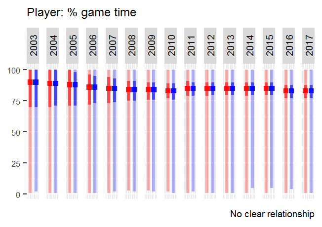

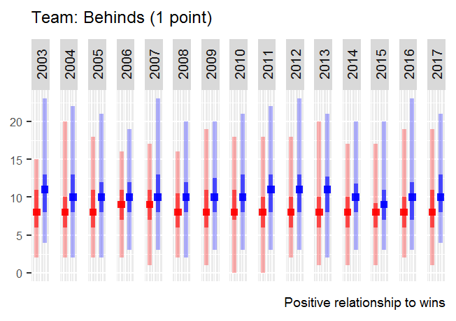

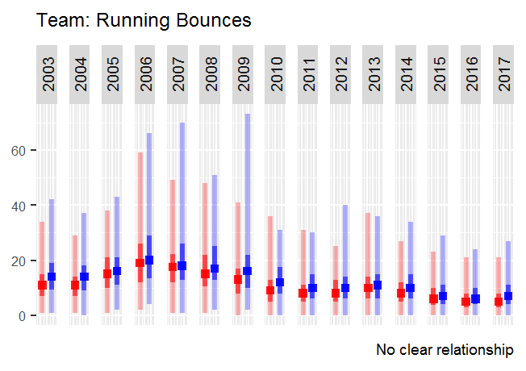

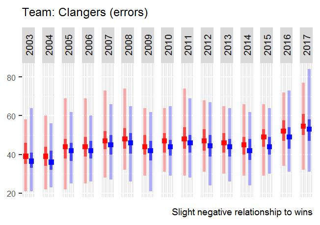

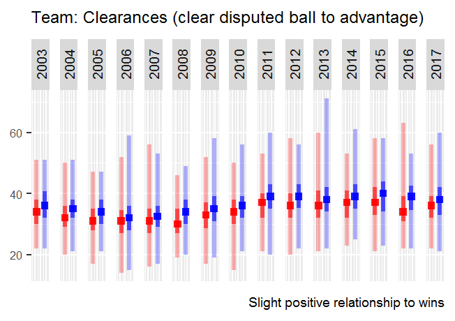

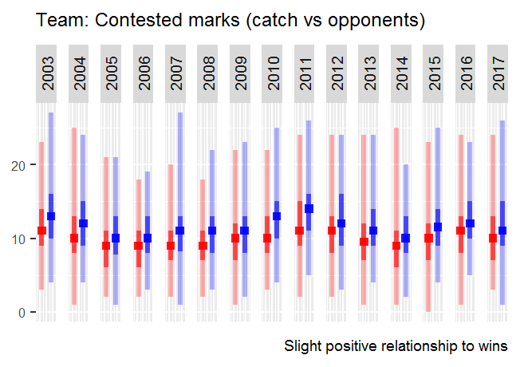

## Exploratory plots - base metrics (pg.2 of 4)

Metrics by year, showing median, IQR and range (Red/LHS = loss or draw, Blue/RHS = win):

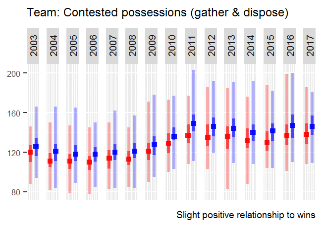

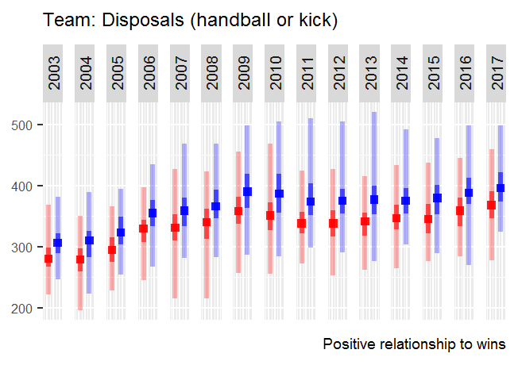

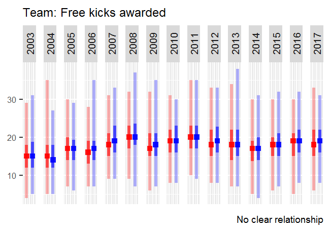

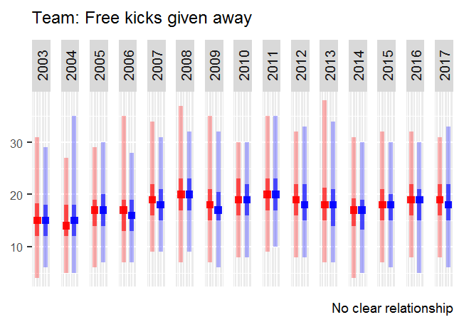

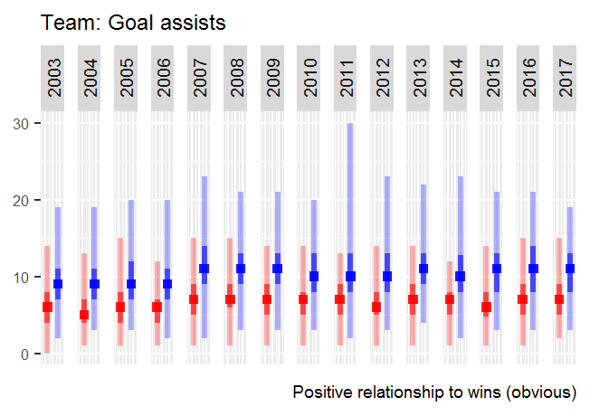

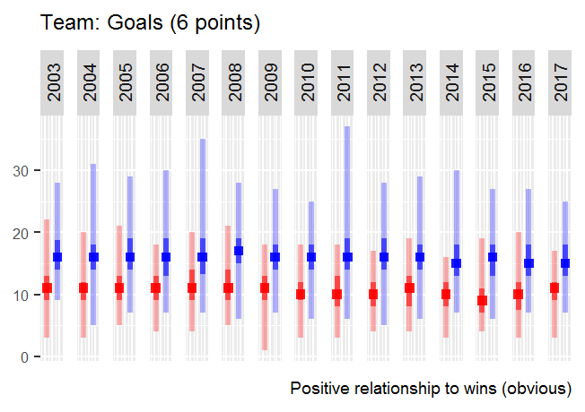

## Exploratory plots - base metrics (pg.3 of 4)

Metrics by year, showing median, IQR and range (Red/LHS = loss or draw, Blue/RHS = win):

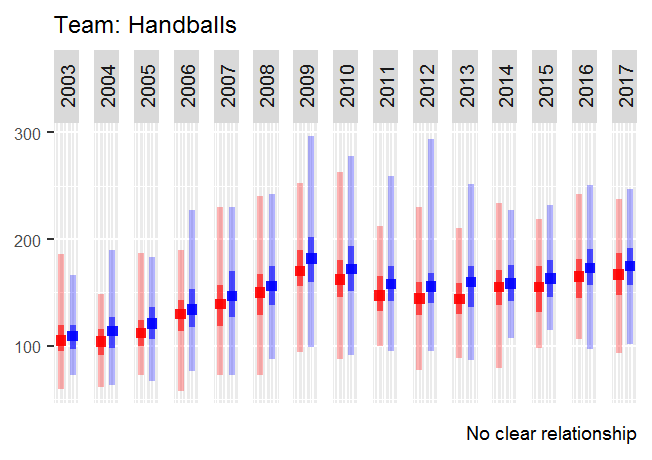

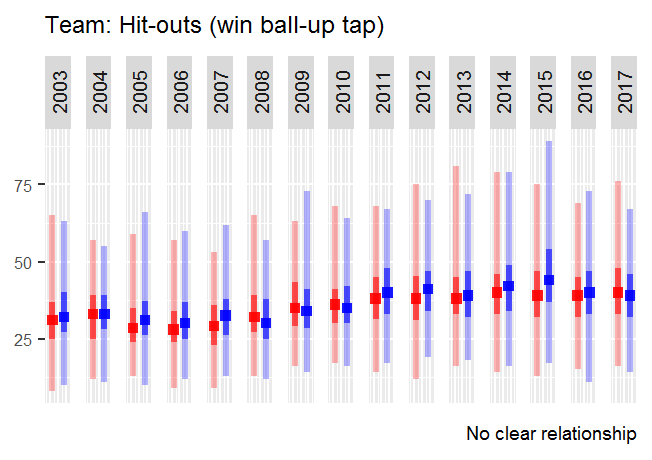

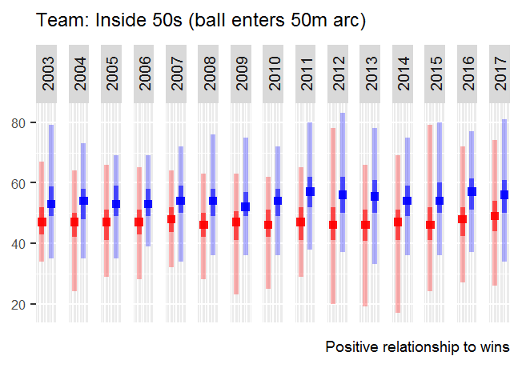

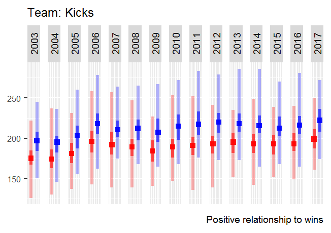

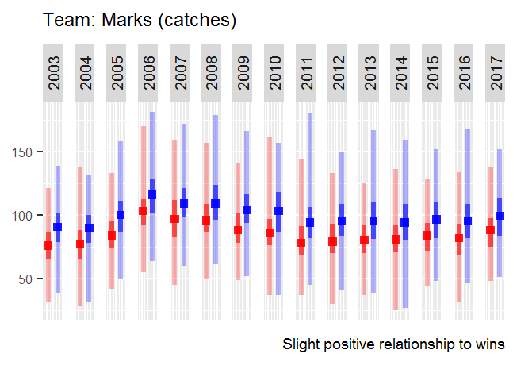

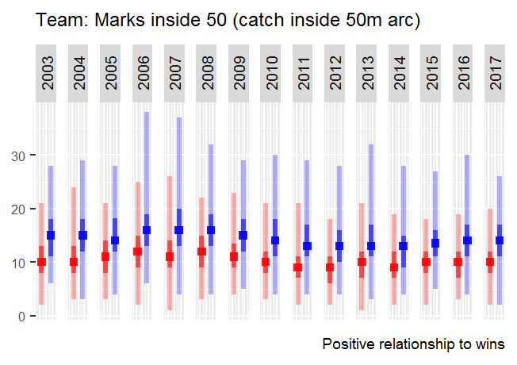

## Exploratory plots - base metrics (pg.4 of 4)

Metrics by year, showing median, IQR and range (Red/LHS = loss or draw, Blue/RHS = win):

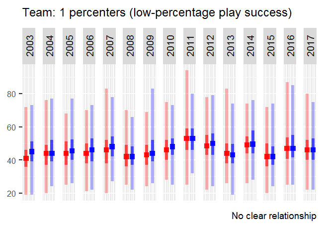

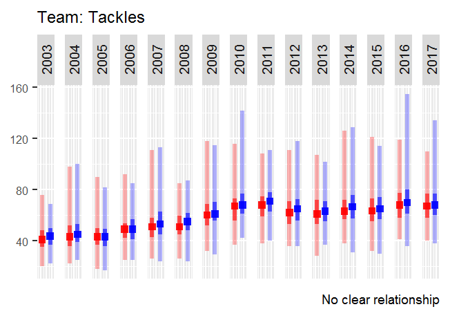

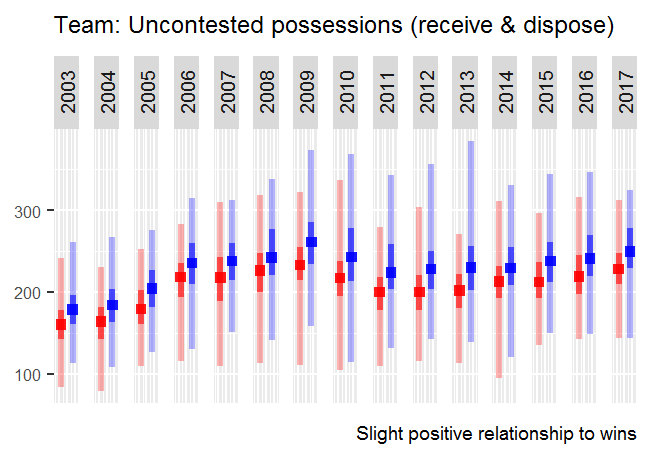

### Insights from base metrics are very limited

Whilst the exploratory analysis highlights some relationships in team-aggregated player metrics, these do not generate usable insights for an AFL team manager or coach. Applying basic game principles, the ability to win is predicated on scoring (measured by Behinds, Goal assists, Goals, Inside 50s, Marks inside 50) which in turn requires the team to possess the ball (measured by Clangers [negator], Disposals, Kicks, Marks, Uncontested possessions). To possess the ball, the team must first win it (Clearances, Contested marks, Contested possessions).

Deeper insights are needed.

## Sport is adversarial

In analysing AFL team performance, it is important to remember the game is adversarial; i.e. player and team outcomes are impacted by the actions of opponents. This provides a vital lense to two key points: 1) the variability in a team's aggregated metrics due to changes in weather conditions etc can be ignored by performing comparisons with the opposing team (in theory, equally impacted by the same conditions), and 2) insight can only truly be gained by considering team metrics in an adversarial context rather than in isolation.

The below code brings in the opposing team's aggregated metrics for each match (some metrics removed as not used further):

```r
# Match-wise (adversarial) view of results
  AFL.by.team.sub <- AFL.by.team %>% select(-Disposals, -Frees, -Hit_outs)
  AFL.by.match <- merge(AFL.by.team.sub, AFL.by.team.sub %>% rename (Team.opp = Team),
                        by.x = c("Year","round","match_id","Team"), by.y = c("Year","round","match_id","vs_opponent"),
                        suffixes = c("",".opp")) %>% select(-vs_opponent) %>% arrange(match_id)

  head(AFL.by.match, 4)
```

```
##   Year round match_id             Team home_away team_result Q1_win Q2_win Q3_win Q4_win ET_win match_score_idx Behinds Bounces Clangers Clearances Contested_marks Contested_possessions Frees_against
## 1 2017   R01     1001          Carlton      home           0      0      0      1      0   <NA>       0.6742424       4       8       49         38              14                   138            12
## 2 2017   R01     1001         Richmond      away           1      1      1      0      1   <NA>       1.4831461       9       3       55         40              11                   149            25
## 3 2017   R01     1002      Collingwood      home           0      0      1      0      1   <NA>       0.8600000      11       2       45         42              12                   161            16
## 4 2017   R01     1002 Western Bulldogs      away           1      1      0      1      0   <NA>       1.1627907       6       3       44         26              12                   135            17
##   Goal_assists Goals Handballs Inside_50s Kicks Marks Marks_inside_50 One_pct Tackles Uncontested_possessions         Team.opp home_away.opp team_result.opp Q1_win.opp Q2_win.opp Q3_win.opp
## 1            8    14       133         48   215    99              15      55      67                     203         Richmond          away               1          1          1          0
## 2           13    20       152         61   200    65              16      33      87                     205          Carlton          home               0          0          0          1
## 3            8    12       185         61   246   118              13      43      67                     276 Western Bulldogs          away               1          1          0          1
## 4           10    15       164         44   228   108               9      62      87                     259      Collingwood          home               0          0          1          0
##   Q4_win.opp ET_win.opp match_score_idx.opp Behinds.opp Bounces.opp Clangers.opp Clearances.opp Contested_marks.opp Contested_possessions.opp Frees_against.opp Goal_assists.opp Goals.opp
## 1          1       <NA>           1.4831461           9           3           55             40                  11                       149                25               13        20
## 2          0       <NA>           0.6742424           4           8           49             38                  14                       138                12                8        14
## 3          0       <NA>           1.1627907           6           3           44             26                  12                       135                17               10        15
## 4          1       <NA>           0.8600000          11           2           45             42                  12                       161                16                8        12
##   Handballs.opp Inside_50s.opp Kicks.opp Marks.opp Marks_inside_50.opp One_pct.opp Tackles.opp Uncontested_possessions.opp
## 1           152             61       200        65                  16          33          87                         205
## 2           133             48       215        99                  15          55          67                         203
## 3           164             44       228       108                   9          62          87                         259
## 4           185             61       246       118                  13          43          67                         276
```

## Sport is adversarial (cont'd)

Using some basic game knowledge, I created indices to compare team performance versus their match opposition. These were:

| Description | Calculation |
| --- | --- |
| Win the ball in contested situations | \(idx.win.ground.ball = \log(contested.possessions/Opp.contested.possessions)\) |
| Mark the ball in contested situations | \(idx.win.aerial.ball = \log(contested.marks/Opp.contested.marks)\) |
| Win first use from scrimmage | \(idx.clear.ball = \log(clearances/Opp.clearances)\) |
| Make less errors than opposition | \(idx.less.clangers = \log(Opp.clangers/clangers)\) |
| Teamwork for goal | \(idx.goal.assist = \log[(goal.assists/goals)/(Opp.goal.assists/Opp.goals)]\) |
| Maintain clear possession | \(idx.mark.kick = \log[(marks/kicks)/(Opp.marks/Opp.kicks)]\) |
| Accurate 50m entries | \(idx.50m.entry = \log[(marks.inside.50/inside.50s)/(Opp.marks.inside.50/Opp.inside.50s)]\) |
| Work hard when not in possession | \(idx.tackle = \log(tackles/Opp.tackles)\) |
| Win one-percenters | \(idx.one.pct = \log(one.pct/Opp.one.pct)\), and |
| Give away less penalties than opposition | \(idx.less.frees = \log(Opp.frees.against/frees.against)\) |

Note: there were three pairs of 0:Inf in the data which were changed to 0.01:1 prior to applying log. Draws were filtered out.

```
##   Year round match_id             Team home_away team_result Q1_win Q2_win Q3_win Q4_win ET_win match_score_idx         Team.opp match_score_idx.opp idx_win_ground_ball idx_win_aerial_ball
## 1 2017   R01     1001          Carlton      home           0      0      0      1      0   <NA>       0.6742424         Richmond           1.4831461         -0.03330718           0.1047354
## 2 2017   R01     1001         Richmond      away           1      1      1      0      1   <NA>       1.4831461          Carlton           0.6742424          0.03330718          -0.1047354
## 3 2017   R01     1002      Collingwood      home           0      0      1      0      1   <NA>       0.8600000 Western Bulldogs           1.1627907          0.07649211           0.0000000
## 4 2017   R01     1002 Western Bulldogs      away           1      1      0      1      0   <NA>       1.1627907      Collingwood           0.8600000         -0.07649211           0.0000000
## 5 2017   R01     1003        Melbourne      away           1      0      1      1      0   <NA>       1.3333333         St Kilda           0.7500000          0.02430253           0.0000000
## 6 2017   R01     1003         St Kilda      home           0      1      0      0      1   <NA>       0.7500000        Melbourne           1.3333333         -0.02430253           0.0000000
##   idx_clear_ball idx_less_clangers idx_goal_assist idx_mark_kick idx_50m_entry  idx_tackle idx_one_pct idx_less_frees
## 1    -0.02227639       0.050166609     -0.05595141   0.151313374    0.07605987 -0.11344445  0.22184875     0.31875876
## 2     0.02227639      -0.050166609      0.05595141  -0.151313374   -0.07605987  0.11344445 -0.22184875    -0.31875876
## 3     0.20827594      -0.009759837      0.00000000   0.005457992    0.01782368 -0.11344445 -0.15892323     0.02632894
## 4    -0.20827594       0.009759837      0.00000000  -0.005457992   -0.01782368  0.11344445  0.15892323    -0.02632894
## 5     0.15209098      -0.070581074      0.23888209   0.130037988    0.12355469  0.06105397  0.07169322    -0.12493874
## 6    -0.15209098       0.070581074     -0.23888209  -0.130037988   -0.12355469 -0.06105397 -0.07169322     0.12493874
```

## Sport is adversarial (cont'd)

The following data and function were created to facilitate mosaic plots on the following pages.

```r
# Create copy of indices for mosaic plots
  AFL.by.match.idx.mosaic <- AFL.by.match.idx %>% select(match_id, Team, team_result, starts_with("idx_")) %>%
    mutate(team_result = factor(team_result, labels = c("Loss", "Win")))
# Create mosaic plot function
  ggplot_mosaic <- function(in_df, X, fillvar, in_cuts, plot_title){
    # Prepare table data from supplied parameters
    xvar <- cut(in_df[[X]], in_cuts)
    mos_df <- as.data.frame.matrix(table(xvar, in_df[[fillvar]]))
    # Calculate the x and y coordinates of the rectangle extremes of each segment
      # start with xmax and xmin
      mos_df$groupSum <- rowSums(mos_df)
      mos_df$xmax <- cumsum(mos_df$groupSum)
      mos_df$xmin <- mos_df$xmax - mos_df$groupSum
      mos_df$groupSum <- NULL
      # Use default row names in variable X so they can be referenced, reshape into long format
      mos_df$xvar <- row.names(mos_df)
      mos_df_melted <- melt(mos_df, id = c("xvar", "xmin", "xmax"), variable.name = "fillvar")
      # Calculate ymax and ymin
      mos_df_melted <- mos_df_melted %>% group_by(xvar) %>% mutate(ymax = cumsum(value/sum(value)), ymin = ymax - value/sum(value))
    # Perform Chi-squared test
      mos_df_chsq <- chisq.test(table(in_df[[fillvar]], xvar))
      # Reshape into long format and identify variables consistent with mos_df_melted
      mos_df_chsq_res <- melt(mos_df_chsq$residuals)
      names(mos_df_chsq_res) <- c("fillvar", "xvar", "residual")
    # Merge data
    mos_df_all <- merge(mos_df_melted, mos_df_chsq_res)
    # Positions for labels
      # x axis: halfway between xmax and xmin of each segment, y axis: one label per FILL group at the right (max)
      mos_df_all$xtext <- mos_df_all$xmin + (mos_df_all$xmax - mos_df_all$xmin)/2
      index <- mos_df_all$xmax == max(mos_df_all$xmax)
      mos_df_all$ytext <- mos_df_all$ymin[index] + (mos_df_all$ymax[index] - mos_df_all$ymin[index])/2
    # Create and return mosaic plot, mapped to x and y coordinates, fill = residuals
    gmos <- ggplot(mos_df_all, aes(ymin = ymin,  ymax = ymax, xmin = xmin, xmax = xmax, fill = residual)) +
      geom_rect(col = "white") + labs(title = plot_title) +
      # Add text to: x axis - effectively tick marks for each X; y axis - one for each FILL
      geom_text(aes(x = xtext, label = xvar), y = 1, size = 2.5, angle = 90, hjust = 1, show.legend = FALSE) +
      geom_text(aes(x = max(xmax),  y = ytext, label = fillvar), size = 3, hjust = 1, show.legend = FALSE) +
      # Fill gradient for residuals per aes mapping (with default 2-color scale), label legend as "Residuals"
      scale_fill_gradient2("Residuals", low = "red", high = "blue") +
      # Place data adjacent to axes (no gap), other appearance changes
      scale_x_continuous("Team results", expand = c(0,0)) + scale_y_continuous("Proportion", expand = c(0,0)) +
      theme(legend.position = "top", legend.key.size = unit(0.2, "cm"), legend.text = element_text(size = 6), legend.title = element_text(size = 7),
            plot.title = element_text(size = 9), axis.title = element_text(size = 7), axis.text = element_text(size = 6))
    print(gmos) }
```

## Exploratory plots - indices (pg.1 of 6)

Indices by year, showing median, IQR and range (Red/LHS = loss, Blue/RHS = win), corresponding mosaic plot:

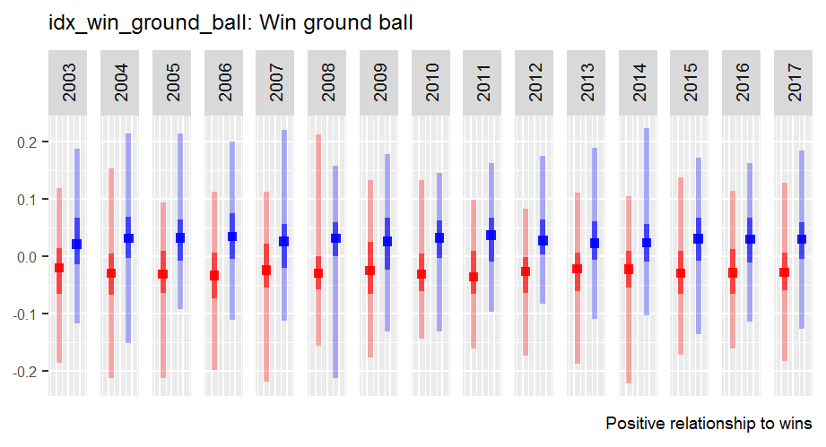

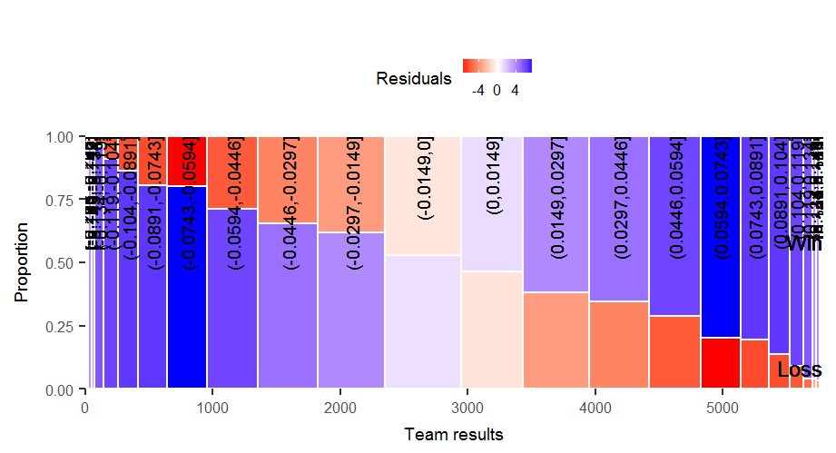

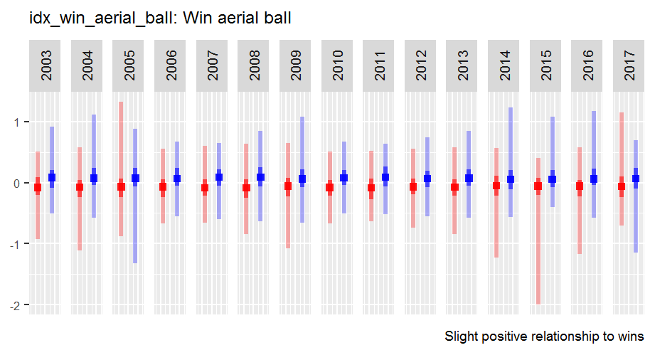

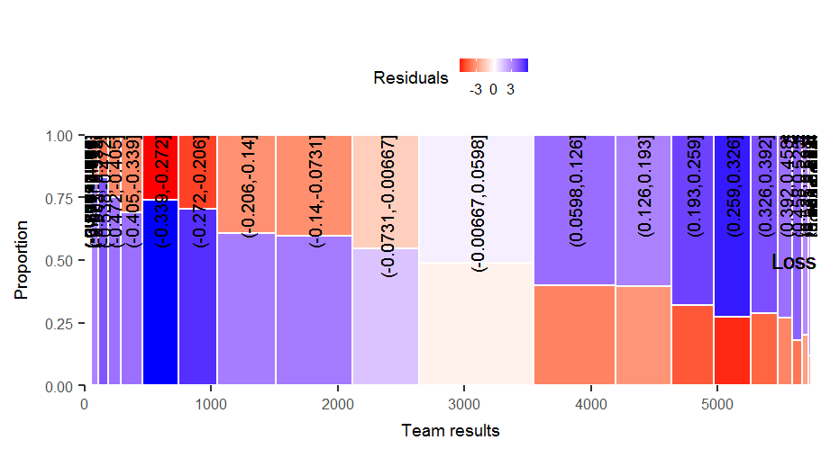

## Exploratory plots - indices (pg.2 of 6)

Indices by year, showing median, IQR and range (Red/LHS = loss, Blue/RHS = win), corresponding mosaic plot:

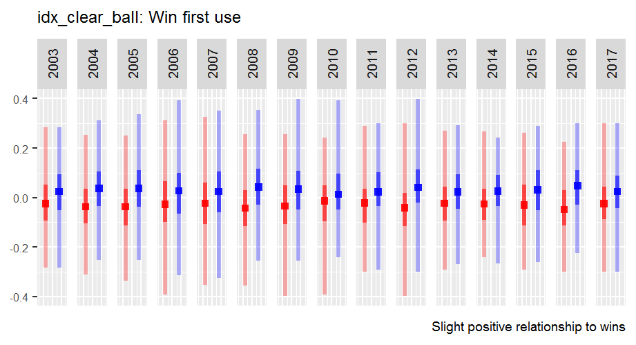

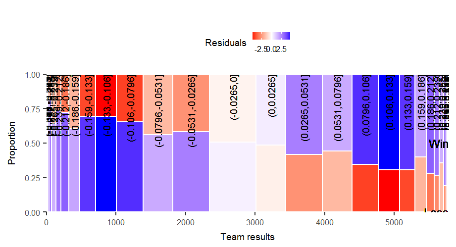

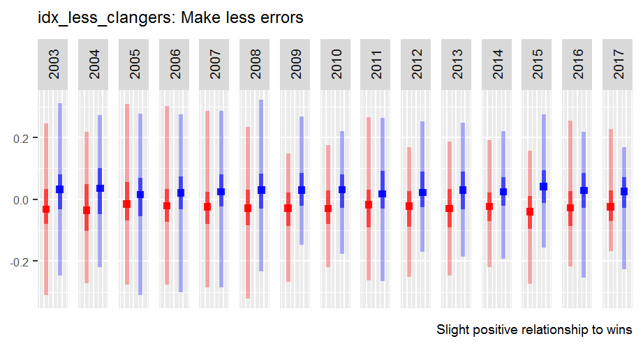

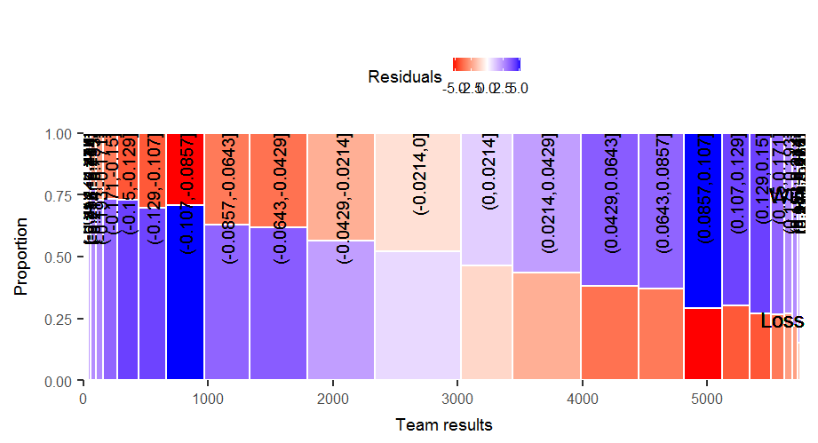

## Exploratory plots - indices (pg.3 of 6)

Indices by year, showing median, IQR and range (Red/LHS = loss, Blue/RHS = win), corresponding mosaic plot:

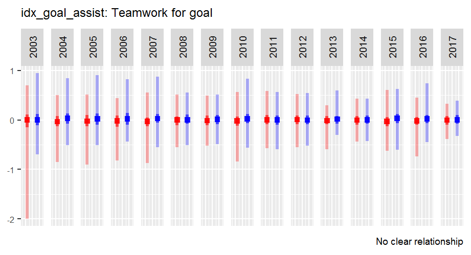

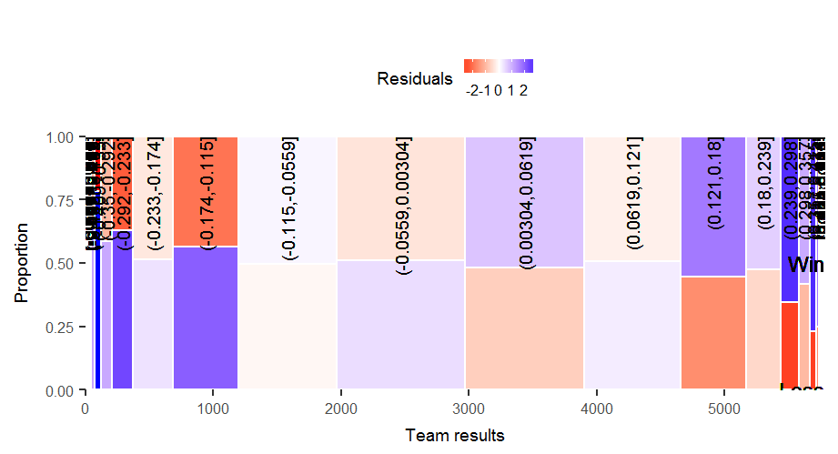

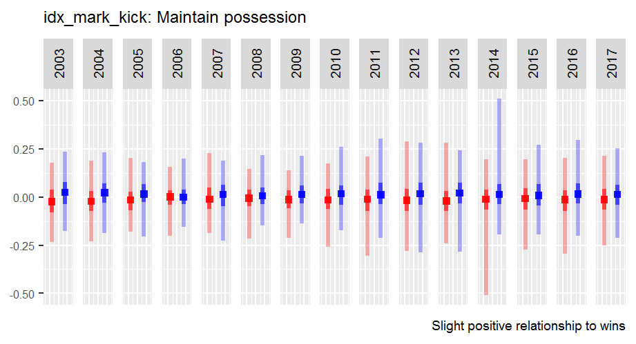

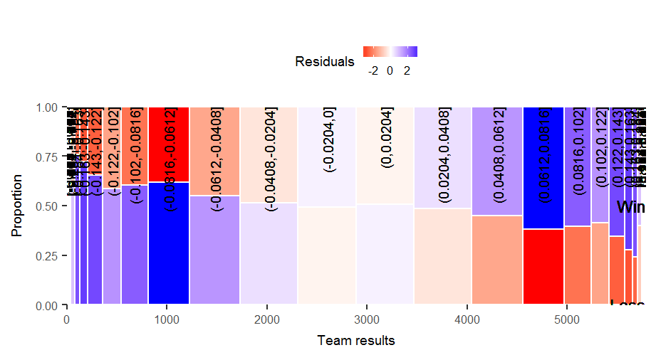

## Exploratory plots - indices (pg.4 of 6)

Indices by year, showing median, IQR and range (Red/LHS = loss, Blue/RHS = win), corresponding mosaic plot:

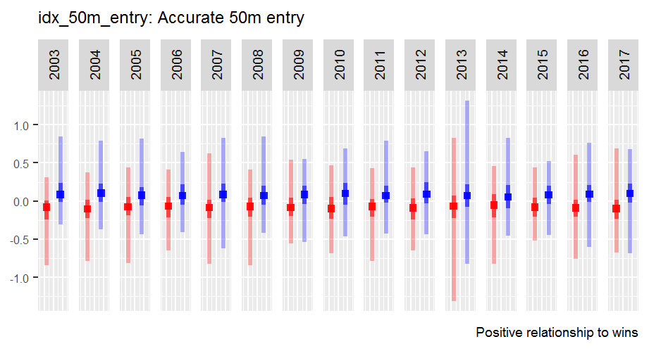

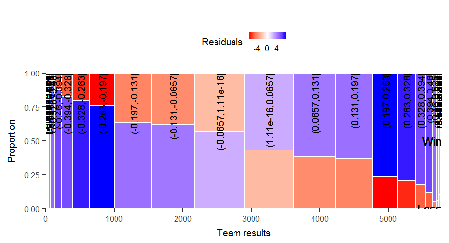

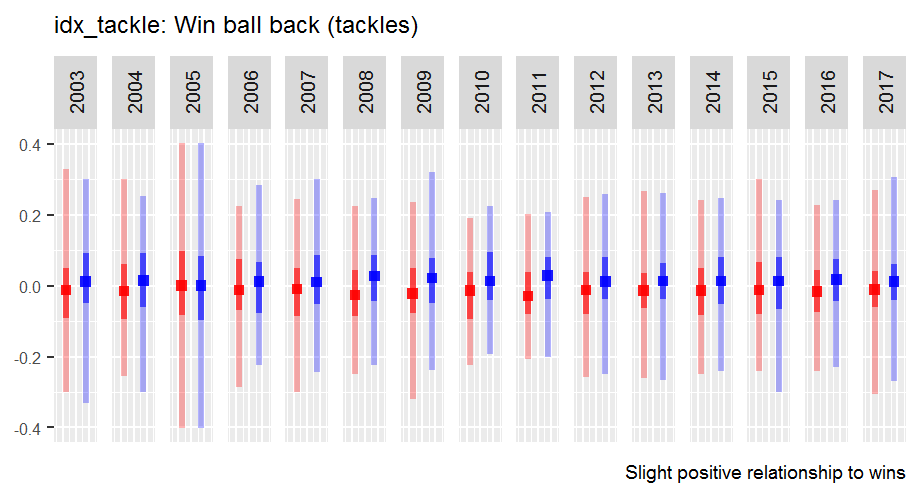

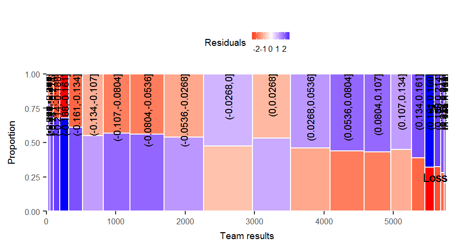

## Exploratory plots - indices (pg.5 of 6)

Indices by year, showing median, IQR and range (Red/LHS = loss, Blue/RHS = win), corresponding mosaic plot:

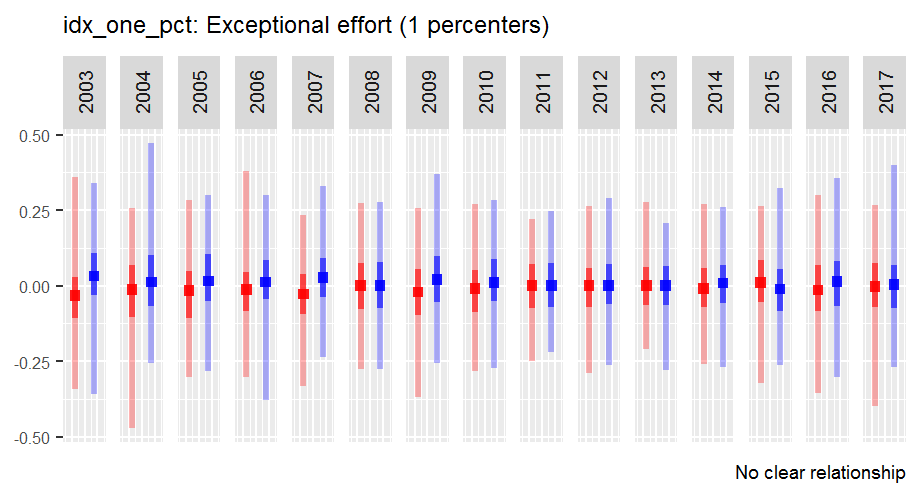

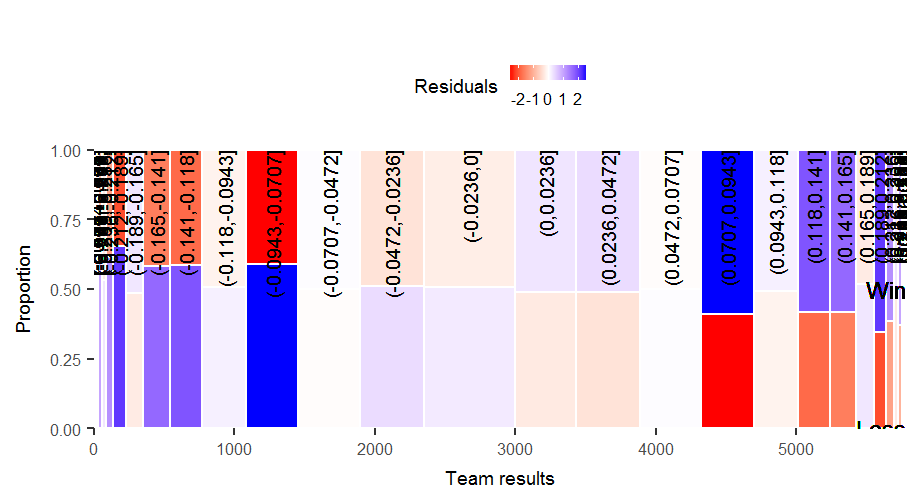

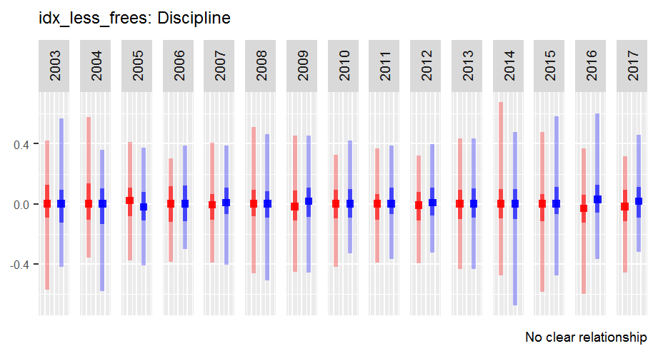

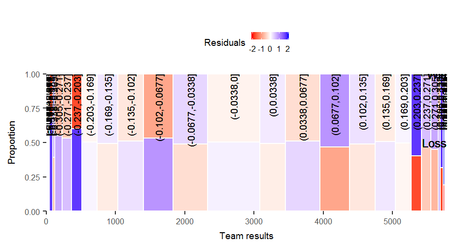

## Exploratory plots - indices (pg.6 of 6)

Finally, to check the distributions of the index data, I created a histogram function (Red/LHS = loss, Blue/RHS = win):

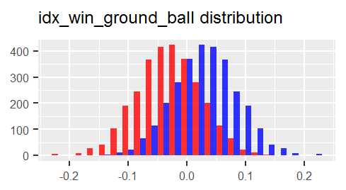

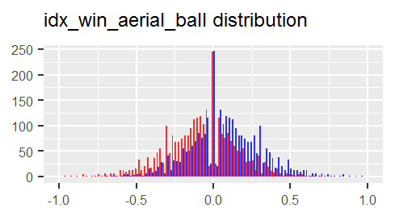

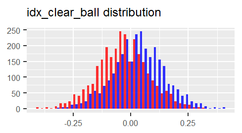

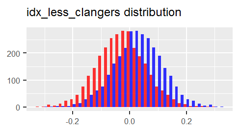

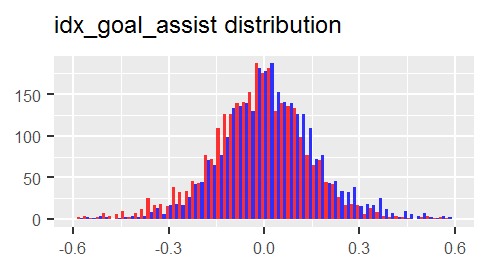

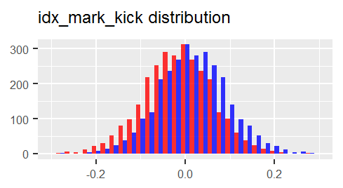

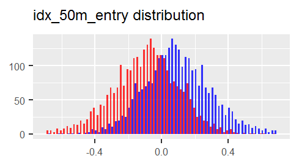

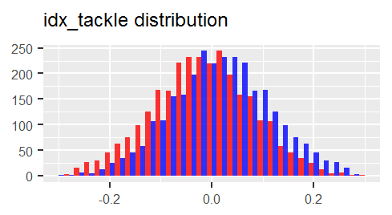

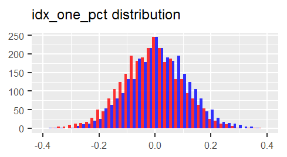

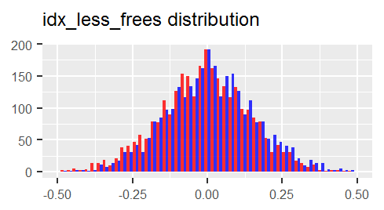

```r
ggplot_hist <- function(in_df, xvar, in_width, plot_title){
  ggph <- ggplot(in_df, aes(x=in_df[[xvar]], fill=team_result)) + geom_histogram(binwidth = in_width, position = position_dodge(in_width), alpha=0.8) +
            scale_fill_manual(labels = c("Loss","Win"), values = c("red","blue")) + labs(title = plot_title, color = "Result") +
            theme(axis.title.x = element_blank(), axis.title.y = element_blank(), axis.text.x = element_text(size = 6),
                  axis.text.y = element_text(size = 6), legend.position = "none", plot.title = element_text(size = 9))
  return(ggph) }
```

## Statistical analysis of indices displaying a relationship

I ran two statistical tests on each "interesting" index: 1) re-randomization of results and 2) significance test.

### Re-randomization: idx_win_ground_ball

I re-randomized the win/loss results of the data 1000 times (commented code was run and results saved).

```r
# AFL.by.match.idx.random <- AFL.by.match.idx %>% select(team_result, starts_with("idx_")) %>% mutate(team_result = sample(0:1, nrow(AFL.by.match.idx.random), replace = TRUE))
# AFL.by.match.idx.random.res <- AFL.by.match.idx.random %>% group_by(team_result) %>%  summarise_all(funs(mean))
# for(i in 2:1000){ AFL.by.match.idx.random$team_result <- sample(0:1, nrow(AFL.by.match.idx.random), replace = TRUE)
#                   AFL.by.match.idx.random.res <- rbind(AFL.by.match.idx.random.res, AFL.by.match.idx.random %>% group_by(team_result) %>% summarise_all(funs(mean))) }
load(file = ".\\AFL_by_match_idx_random_res.Rda")
Xbar <- AFL.by.match.idx %>% select(team_result, starts_with("idx_")) %>% group_by(team_result) %>% summarise(mean(idx_win_ground_ball))
print(as.list(AFL.by.match.idx.random.res %>% filter(team_result == 1 & (idx_win_ground_ball <= Xbar[[2]][[1]] | idx_win_ground_ball >= Xbar[[2]][[2]])) %>% count()))
```

```
## $n
## [1] 0
```

There were zero re-randomisations with a mean equal to or greater than the mean of idx_win_ground_ball for Wins, so the first test indicates the result is **not random**.

### Significance test: idx_win_ground_ball

```r
  print(as.data.frame(AFL.by.match.idx %>% group_by(team_result) %>% summarise(mean(idx_win_ground_ball), sd(idx_win_ground_ball), n())))
```

```
##   team_result mean(idx_win_ground_ball) sd(idx_win_ground_ball)  n()
## 1           0               -0.02814632              0.05430982 2891
## 2           1                0.02814632              0.05430982 2891
```

We assume the probability of winning any match is random (0.5). Null hypothesis: idx_win_ground_ball has no impact to the match result so its true mean is 0; \(H_0:\mu=0\). Let X be the random variable idx_win_ground_ball in Wins.

Assuming \(\sigma=s=0.054310\), \(z_\bar{X} = (0.028146-\mu)/\sigma = (0.028146-0)/0.054310 = 0.52\) This z-score corresponds to a probability of 0.6985 so the team leading idx_win_ground_ball in an AFL match should win approximately 70% of the time **(Strong relationship)**.

## Statistical analysis of indices displaying a relationship (cont'd)

Performing the same two tests on the remaining indices yielded these results:

[output not shown]

Interestingly, none of the indices tested as being random but most of them are fairly weak indicators of success if we regard the benchmark as being a 50% win rate.

## Selecting indices for machine learning

How strongly are the indices correlated with winning and with each other?

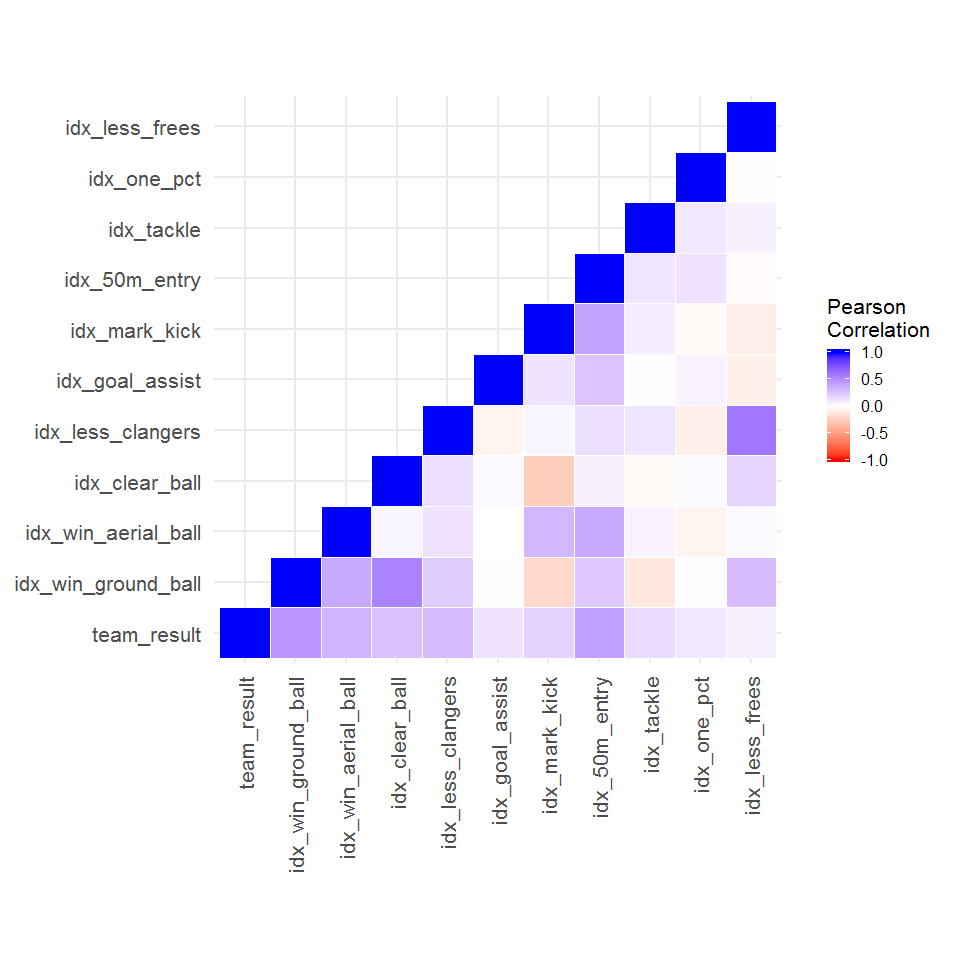

## Selecting indices for machine learning (cont'd)

Which indices are worth exploring further through machine learning and modelling?

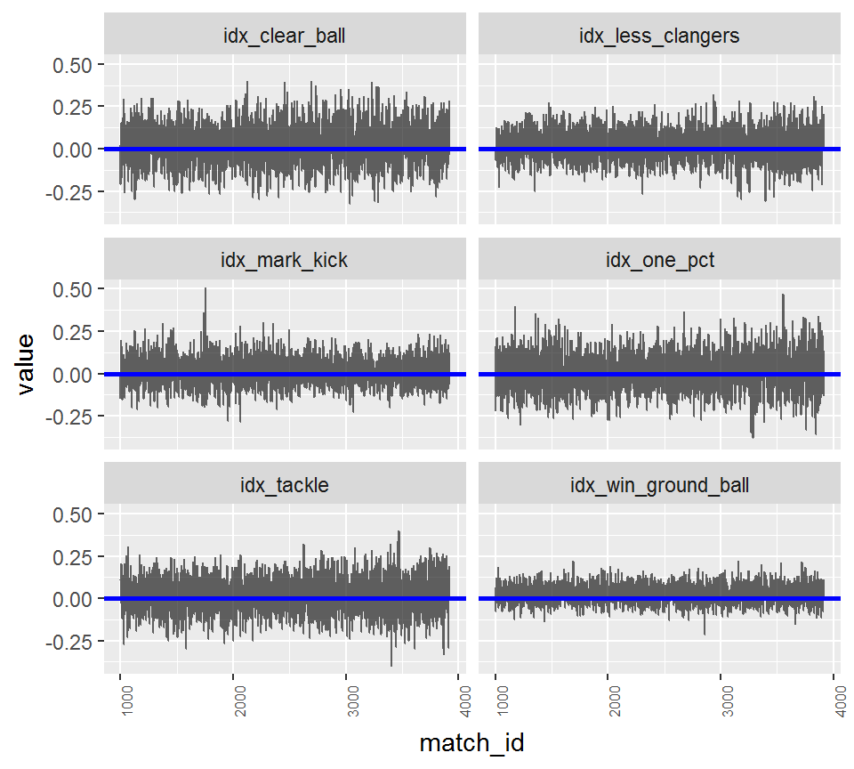

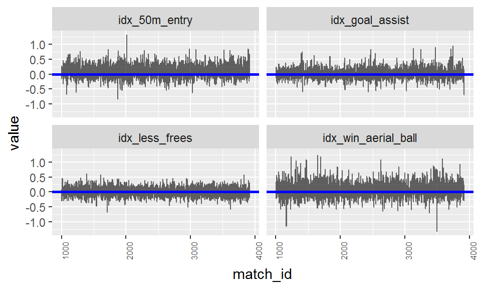

## Selecting indices for machine learning (cont'd)

The indices with the strongest statistical and visual relationship to wins are:

- idx_win_ground_ball
- idx_win_aerial_ball
- idx_clear_ball
- idx_50m_entry
- idx_less_clangers

I have also included idx_less_frees as it displays some correlation with idx_win_ground_ball and idx_less_clangers. These indices will need some feature engineering to boost their performance in predictive modelling so some deep-dive analysis is required.